# BBAN4001 Data Science - Arbeidskrav

## Innledning

I denne oppgaven vil vi bruke et datasett som heter UniversalBank og bruke Naïve Bayes og k-NN for å lage en modell som kan si om kunden har fått eller ikke basert på kunden sin data. Først vil vi gjøre litt eksplorativ dataanalyse ved å framstille dataen i forskjellige plotter. Videre vil vi bruke Naïve Bayes og k-NN på datasettet. Tilslutt, vil vi sammenligne og drøfte resultatene. Gjennom oppgaven vil vi prøve å svare på problemstillingen: *Hva er forskjellen på Naïve Bayes og k-NN i datasettet UniversalBank* Vi har valgt å bruke Naïve Bayes og k-NN, fordi begge er veldig forskjellige modeller, men fremedeles vil gi oss studenter en god grunnfortåelse over klassifisering algoritmer.

## Data

```python
# Import dependencies
import pandas as pd
import numpy as np

from sklearn import preprocessing
from sklearn.model_selection import train_test_split

from sklearn.metrics import accuracy_score
from sklearn.metrics import f1_score
from sklearn.metrics import confusion_matrix

from sklearn.neighbors import NearestNeighbors, KNeighborsClassifier
from sklearn.naive_bayes import GaussianNB

import matplotlib.pylab as plt
import seaborn as sns
```

```python
#Read the CSV-file
dataset = pd.read_csv("UniversalBank.csv")
dataset.head()
```

|  | ID | Age | Experience | Income | ZIP Code | Family | CCAvg | Education | Mortgage | Personal Loan | Securities Account | CD Account | Online | CreditCard |
| --- | --- | --- | --- | --- | --- | --- | --- | --- | --- | --- | --- | --- | --- | --- |
| 0 | 1 | 25 | 1 | 49 | 91107 | 4 | 1.6 | 1 | 0 | 0 | 1 | 0 | 0 | 0 |
| 1 | 2 | 45 | 19 | 34 | 90089 | 3 | 1.5 | 1 | 0 | 0 | 1 | 0 | 0 | 0 |
| 2 | 3 | 39 | 15 | 11 | 94720 | 1 | 1.0 | 1 | 0 | 0 | 0 | 0 | 0 | 0 |
| 3 | 4 | 35 | 9 | 100 | 94112 | 1 | 2.7 | 2 | 0 | 0 | 0 | 0 | 0 | 0 |
| 4 | 5 | 35 | 8 | 45 | 91330 | 4 | 1.0 | 2 | 0 | 0 | 0 | 0 | 0 | 1 |

Det er viktig å etablere en innledende forståelse for å bedre forstå dataen vi arbeider med. Datasettet er fra en bank og inneholder profilen til 5000 forskjellige kunder. Innad profilen deres er mange forskjellige variabler som: alder, erfaring, inntekt, post nummer, familie størrelse, Crash Credit gjennomsnitt, utdanning, osv. Nedenfor er en oversikt og beskrivelse over alle variablene

[figure not shown]

For preprosessering, blir noen variabler droppet og noen kolonner flyttet. Vi velger å droppe ID og ZIP Kode siden det er personlig data og er irrelevant for vår oppgave. Her kan det velges å lage dummy variabler for familie eller utdanning, men velges at det er unødvendig siden de er ordinal og ikke kategorisk.

```python
#Drop columns ID and ZIP Code
dataset = dataset.drop(columns=['ID', 'ZIP Code'])

#Rename columns
dataset.rename(
    columns={"Family": "Family_Size",
             "CCAvg": "CreditCashAvg",
             "Personal Loan": "Accepted_Loan",
             "Securities Account": "Sec_Acc",
             "CD Account":"CD_Acc"},
    inplace=True,
)

#Move personal loan to end of the df
personal_loan = dataset.pop("Accepted_Loan")
dataset["Accepted_Loan"] = personal_loan
#Husk å skifte navn på alle fra mellom rom til understrek
```

For å bedre bli kjent med datasettet, har det blitt gjort litt eksplorativ dataanalyse. Den første visualisering vi har gjort er en side-by-side box plot som viser oss distribusjonen av de numeriske verdiene, hvor vi skiller mellom kunder som har fått lån og dem som har ikke. 50% av verdiene ligger innenfor boksen, den grønnestrekken viser hvor medianen, og sirklene er uteliggere. Ut ifra boxplotten har de som har fått lån vanligvis høyere utdanning, inntekt, creditcashavg og en større familie. Men det er en del uteliggere i inntekt og creditcashavg sammenlignet med familiestørresle og utdanning. Dette kan være fordi familiestørrelse og utdanning har større spredning. Videre ser vi at alder og erfaring har lite å si om man får lån.

```
[]
```

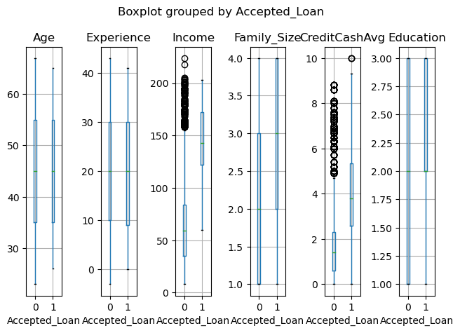

```python
# side-by-side boxplots for Age, Experience, Income, Family, CCAvg, Education
fig, axes = plt.subplots(nrows=1, ncols=6)
dataset.boxplot(column="Age", by="Accepted_Loan", ax=axes[0])
dataset.boxplot(column="Experience", by="Accepted_Loan", ax=axes[1])
dataset.boxplot(column="Income", by="Accepted_Loan", ax=axes[2])
dataset.boxplot(column="Family_Size", by="Accepted_Loan", ax=axes[3])
dataset.boxplot(column="CreditCashAvg", by="Accepted_Loan", ax=axes[4])
dataset.boxplot(column="Education", by="Accepted_Loan", ax=axes[5])

for ax in axes:
    ax.set_label("Accepted_Loan")
plt.tight_layout()
plt.plot()
```

Det er viktig å etablere en innledende forståelse for å bedre forstå dataen vi arbeider med. Gjennom korrelasjonstabellen kan vi etablere en forståelse over hvilke datapunkter som har korrelasjon med hverandre - altså hvilke punkter som beveger seg i samsvar med hverandre. Jo høyere tallet er, desto mer korrelasjon er det mellom punktene, med 1 som fullstendig korrelasjon mellom punktene. Dersom tallet er negativt vil det være negativ korrelasjon, som betyr at dersom den ene variabelen øker så synker den andre.

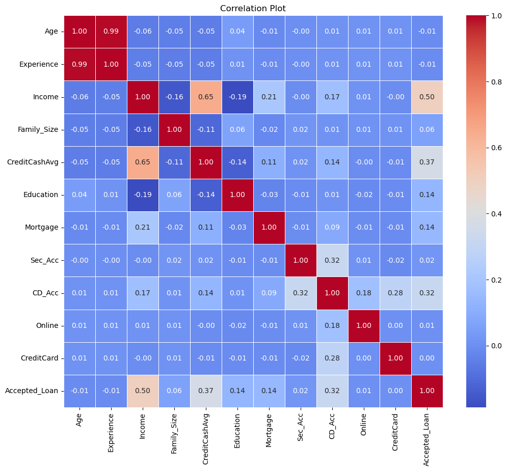

```python
#Heatmap
corr_matrix = dataset.corr()

# Set up the matplotlib figure
plt.figure(figsize=(12, 10))

# Create a heatmap using seaborn to visualize the correlation matrix
sns.heatmap(corr_matrix, annot=True, cmap='coolwarm', fmt=".2f", linewidths=0.5)

# Show the plot
plt.title('Correlation Plot')
plt.show()
```

Gjennom korrelasjonsplott får vi bedre forståelse for hvilke datapunkter som er viktigst, og har størst påvirkningskraft for hverandre. Vi trekker videre frem korrelasjonen mellom “Akseptert_lån” og resten av punktene. Vi ser da at income er den med mest korrelasjon med “Aksseptert_lån”, mens “Credit_CashAvg” og “CD_Acc” også er viktige.

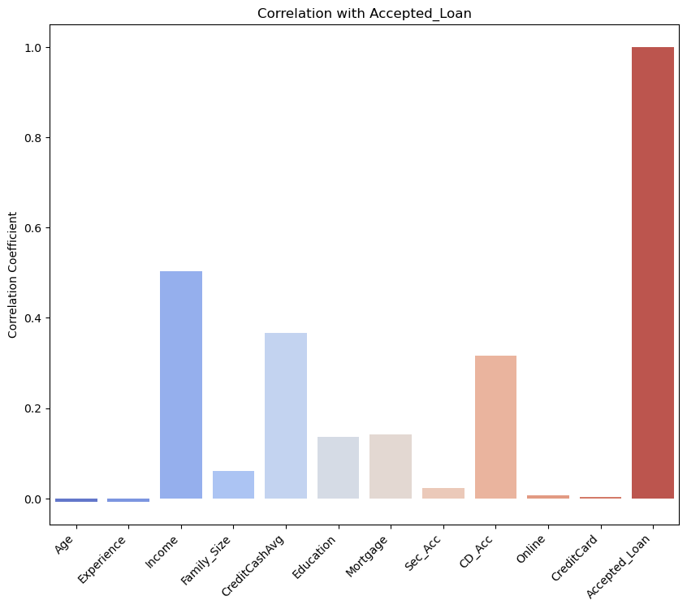

```python
# Calculate the correlation matrix with respect to the "Personal Loan" column
personal_loan_corr = dataset.corr()["Accepted_Loan"]

# Set up the matplotlib figure
plt.figure(figsize=(10, 8))

# Create a bar plot to visualize correlations with "Personal Loan"
sns.barplot(x=personal_loan_corr.index, y=personal_loan_corr.values, palette='coolwarm')

# Show the plot
plt.title('Correlation with Accepted_Loan')
plt.ylabel('Correlation Coefficient')
plt.xticks(rotation=45, ha='right')
plt.show()
```

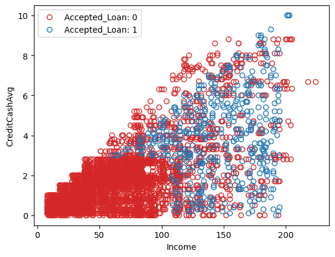

```python
#ScatterPlot with colour-coded outcomes
#dataset.plot.scatter(x="Income", y ="CCAvg", c=['C0' if c ==1 else 'C1' for c in dataset.Personal_Loan])
fig, ax = plt.subplots()
for pl, color in (0, 'C3'), (1, 'C0'):
    subset_df = dataset[dataset.Accepted_Loan == pl]
    ax. scatter(subset_df.Income, subset_df.CreditCashAvg, color='none', edgecolor=color)
ax.set_xlabel("Income")
ax.set_ylabel("CreditCashAvg")
ax.legend(["Accepted_Loan: 0", "Accepted_Loan: 1"])
plt.show()
```

På grunn av at “Income” trekker seg ut som viktig ønsker vi å se litt videre på det datapunktet. Her vil vi forsikre oss at det ikke biased mot en urealistisk retning, og det ikke er noen enkelt caser som vil påvirke resultatet veldig. I plottet under har vi visualisert hvor mange som har de forskjellige inntektene i en linjediagram. Vi har videre visualisert de punktene hvor populasjonen er over 50 som rødt, og de under som blått. Dette er for å visualisere at den største populasjonen har inntekt under ca. 75. Vi har også gjort en telling som viser at det er totalt 3778 individer som tjener under 100 og 1222 individer som har inntekt over 100. Dette gir oss et bilde på hvordan inntekts bildet til populasjonen er bygd sammen.

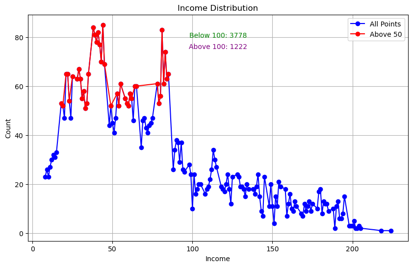

```python
# Prepare the data
income_distribution = dataset['Income'].value_counts().sort_index()

# Calculate counts below and above 100
below_100 = income_distribution[income_distribution.index < 100].sum()
above_100 = income_distribution[income_distribution.index >= 100].sum()

# Plotting the line plot with points above 50 in red
plt.figure(figsize=(10, 6))
income_distribution.plot(kind='line', marker='o', linestyle='-', color='blue', label='All Points')
income_distribution[income_distribution > 50].plot(kind='line', marker='o', linestyle='-', color='red', label='Above 50')

# Add annotations for counts below and above 100
plt.annotate(f'Below 100: {below_100}', xy=(0.5, 0.9), xycoords='axes fraction', ha='center', color='green')
plt.annotate(f'Above 100: {above_100}', xy=(0.5, 0.85), xycoords='axes fraction', ha='center', color='purple')

plt.title('Income Distribution')
plt.xlabel('Income')
plt.ylabel('Count')
plt.legend()
plt.grid(True)
plt.show()
```

```python
#Check how many customers have accepted a loan
has_accepted_loan = dataset['Accepted_Loan'].value_counts().sort_index()
print(has_accepted_loan)
```

```
0    4520
1     480
Name: Accepted_Loan, dtype: int64
```

Her ser vi at det er mange flere som har ikke fått lånt enn som har fått lånt. Noe som peker på at datasettet er betydelig ubalanset.

Før vi forklarer de valgte modellene og bruker dem på dataene, har vi laget en pytonfunksjon for å evaluere begge modellene. Funksjonen beregnet og printet: Accuracy, F1 Score, Sensitivity, Specificity, Prescision og Confusion Matrix.

```python
# Evaluate the model
def evaluate(x_test, y_pred):
    accuracy = accuracy_score(y_test, y_pred)
    print(f"Accuracy: {accuracy:.2f}")

    fom1 = f1_score(y_test, y_pred)
    print(f"f1: {fom1:.2f}")


    # Confusion Matrix
    conf_matrix = confusion_matrix(y_test, y_pred)
    sns.heatmap(conf_matrix, cbar=False, annot=True, fmt="d", cmap="Blues")
    plt.xlabel("Predicted")
    plt.ylabel("Actual")
    plt.show()

    true_positive = conf_matrix[1][1]
    true_negative = conf_matrix[0][0]
    false_positive = conf_matrix[1][0]
    false_negative = conf_matrix[0][1]

    accuracy_validation = (true_positive + true_negative)/ (np.sum(conf_matrix))
    sensitivity =  true_positive/(true_positive + false_negative)
    specificity = true_negative/(true_negative + false_positive)
    precision =  true_positive/(true_positive + false_positive)

    print(f"Confirm accuracy: {accuracy_validation: .2f}")
    print(f"Sensitivity: {sensitivity: .2f}")
    print(f"Specificity: {specificity: .2f}")
    print(f"prescision: {precision: .2f}")
```

## Metode 1: k-Nearest Neighbor

k-NN algoritmen er en classifier som klassifiserer ny data ved hjelp av eksisterende naboer. Det kan bli brukt som en classifier eller en numerisk predictor, men i denne oppgaven blir det brukt som en classifier. Algoritmen ser på de treningsdataen til et datapunkt, også klassifisere punktet ut ifra hvor nærme det nye punktet er til de treningsdataen.

For å finne ut av hvilke datapunkt er nærmest, må man regne avstanden mellom punktene. Det er flere måter å gjøre dette på, men euklidsk avstand er den mest vanlig. Man finner den euklidske avstanden ved hjelp av denne formelen:

$$\sqrt{(x_1-u_1)^2+(x_2-u_2)^2+...+(x_p-u_p)^2}$$

Etter man finner avstanden mellom det nye punktet og eksisterende punktet, trenger man å bestemme k-verdien. K-verdien bestemmer hvor mange punkter man skal bruke for å klassifisere. F.eks. Hvis k=3, ser algoritmen på de tre nærmeste punktene og ser hvilken klasse de tilhører; om to av de punktene er av klasse A og en av de er B, blir det nye punktet klasse A. Videre hvis k=1 ser algoritmen bare på det nærmeste punktet og det nye punktet blir helt lik klasse som det nærmeste punktet. Man kan da si at algortimen bruker en flertallsregel for klassifisere punktet, hvor man ser på k mengde naboer blir brukt for å "stemme". Siden k skal bestemme antall datapunkter man skal bruke, burde man ikke velge et partall fordi da blir det uavgjort. Vanligvis kan man bruke k=sqrt(n), hvor n er antall datapunkter man har. Her er det viktig å enten runde opp eller ned så man ikke får partall.

```python
#Partition Data
x = dataset.iloc[:, 0:-2]
y = dataset.iloc[:, -1]
X_train, X_test, y_train, y_test = train_test_split(x, y, random_state=4, test_size =  0.2)

#Scale Data
scaler_x = preprocessing.StandardScaler()
X_train_scaled = scaler_x.fit_transform(X_train)
X_test_scaled = scaler_x.transform(X_test)

#Train kNN Model | Here k = 71 as the the sqrt(5000) = 71
classifier = KNeighborsClassifier(n_neighbors = 71, p=2, metric="euclidean")
classifier.fit(X_train_scaled, y_train)
#Make prediction
y_pred = classifier.predict(X_test_scaled)
```

```
Accuracy: 0.94
f1: 0.42
```

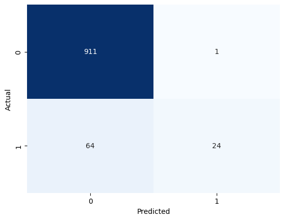

```
Confirm accuracy:  0.94
Sensitivity:  0.96
Specificity:  0.93
prescision:  0.27
```

```python
#Evaluate model
evaluate(y_test, y_pred)
```

## Metode 2: Naive Bayes classifier

Bayes sin metode handler om at en kan trene en maskin med P(X|Y), som vil gjøre at den kan løse P(Y|X). Altså kan Bayes metode brukes for å forstå hvor sannsynlig vil utfall X inntreffe dersom utfall Y inntreffer. Modellen vil bli matet inn med informasjon gjennom treningsdata, som vil gjøre det mulig å forutsi senere instanser. Dersom vi baserer oss på datasettet vårt, kan vi altså vurdere hvor sannsynlig en med online bank bruker et kredittkort?

I datasettet vårt er det flere X tilfeller, altså flere faktorer som kan være med i å påvirke Y. Det er da Naive Bayes blir relevant. Her antar vi at hver av faktorene er uavhengige av hverandre, og ser på hvordan hver av dem kan påvirke utfallet av X.

Naive Bayes er en god modell av flere grunner. Den er enkel å gjennomføre, egner seg godt på store datasett, gir gode resultater og er veldig fleksibel. Likevel er antagelsen om at datapunktene er uavhengige sjeldent helt korrekt, og den må derfor vurderes om litt unøyaktighet er hensiktsmessig (Zhang, 2004)(Shmueli et. al., 2017)

\begin{equation*} P(x_{i}\mid y) = \frac{1}{\sqrt{2\pi \sigma_y^{2}}} \exp \left(-\frac{(x_{i} -\mu_{y})^2}{2\sigma_y^{2}} \right) \end{equation*}

```
Accuracy: 0.90
f1: 0.52
```

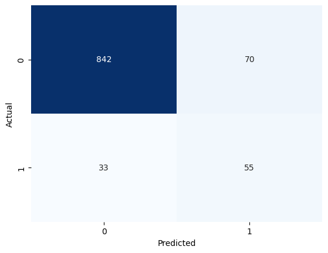

```
Confirm accuracy:  0.90
Sensitivity:  0.44
Specificity:  0.96
prescision:  0.62
```

```python
# Create a Naïve Bayes model
model = GaussianNB()

# Train the model
model.fit(X_train, y_train)

# Make predictions on the test set
y_pred = model.predict(X_test)

#Evaluate Model
evaluate(y_test,y_pred)
```

## Sammenligning og Drøfting

Det er flere forskjeller mellom metodene vi har valgt. Både KNN og Naïve Bayes er relativ enkle modeller, og egner seg godt som introduserende data-analyse metoder. Begge modellene er supervised, som betyr at den blir matet inn med datasett hvor vi allerede definerer hva som er korrekt. Likevel egner KNN og Naïve Bayes seg til forskjellige arbeidsoppgaver.

Naïve Bayes er en lineær klassifiseringsmetode. Dette betyr at en separerer datasettet med en linje som separerer hvilken kategori nodene vil være kategorisert under. Dette gjør at Naïve Bayes er raskere enn KNN, som er en ikke-lineær klassifiseringsmetode. I denne oppgaven vil det Naïve Bayes slite siden modellen kan være sensetiv til irrelevante variabler. Dette kunne bli fikset ved å redusere dimensjoner og fjerne unødvendig støy for modellen, og som vi så i korrelasjonsplottet var det noen variabler som ikke mye korrelasjon med "Accepted_Loan". I instanser hvor en ikke kan lage en vilkårlig lineær separasjon vil ikke-lineære metoder være bedre.

Med store datasett vil Naïve Bayes være nøyaktig og skalerer bra med større datasett. KNN kan også få høy nøyaktighet med økning av K verdien, men vil slite med større datasett med tanke på fart og effektivitet, siden det er en "Lazy Learner". Det vil trenge å bergene avstanden til naboene for hvert ny punkt. På grunn av det prøver å finne nærmeste naboen vil k-NN slite, hvis det er mange uteliggere som kan påvirke klassifiseringen. Vi tidligere så i scatterplotten og boxplotten at det er en del uteliggere i datasettet. k-NN er svært gunstig i situasjoner hvor situasjonell uavhengighet ikke er reelt.

**Vurdering av modellene:**

For å sammenligne modellene våre bruker vi 4 vurderingskriterier. Disse er accuracy, sensitivity, specificity og precision. Accuracy gir uttrykk for helhetlig nøyaktighet hos modellen - altså hvor ofte forutser den korrekt svar. Men som vi vil se i denne delen av rapporten så sier den ingenting om hvordan modellen spesefikt håndterer falske positive eller falske negative svar. Derfor er det viktig å bruke de tre andre kriteriene også får å få bedre forståelse for hvordan modellen gjør det i forskjellige tilfeller.

| Original | Forkortelse |
| --- | --- |
| False Positve | FP |
| False Negative | FN |
| True Positive | TP |
| True Negative | TN |

[output not shown]

(Gurav, 2023)

**Feilanalyse**

Det er også flere punkter som gjør at modellene får dårligere resultat enn ønskelig. Det hadde vært relevant å ha et mer omfattende datasett, som enklere kunne balansere seg. Dersom en skulle balansert datasettet i dag, ville vi kun hatt en populasjon på 1000. 5000 er allerede et ikke ideelt tall, og 1000 vil gi enda mer unøyaktige svar. Med et så ubalansert datasett vil det være vanskelig å få et godt resultat med Naïve Bayes metode.

Det er relativt få features i datasettet. Det er flere faktorer som kan ha påvirkning som ikke blir gjort til rette for. Flere sosioøkonomiske faktorer som hadde vært relevant å se på mangler. For eksempel kunne informasjon om foreldres inntekt interessant og vurdere. Videre ligger det ikke informasjon om at individet har mislykket å nedbetale lån tidligere. Det er derfor flere features som kunne belyst saken videre.

Som tidligere nevnt kunne det vært relevant å dummykode enkelte deler av datasettet, og det er mulig det hadde gitt mer utdypende svar.

## Konklusjon

Vi har gjort eksplorativ dataanalyse, hvor vi har utforsket dataen ved hjelp av forskjellige figurer som: box-plots, heatmaps, scatterplots, og barplots. Med dataanalyse så har vi forstått trender og mønster i dataen som kan være viktig for å tolke resultatene våre. Denne delen av oppgaven var interessant og vi fikk lære om hvordan man setter opp forskjellige plots med matplotlib, pandas og seaborn.

Videre brukte vi datasettet med k-NN og Naïve Bayes metodene for å lage en klassifiseringsmodell. Denne delen gikk veldig bra og her fikk vi lære om hvordan man anvender de teoretiske formlene vi har lest om i en mer praktisk sammenheng i form av noen enkle linjer med kode. Vi ble overrasket over hvor enkelt det var, selv om teorien bak modellene er mye mer avansert.

Til slutt drøftet vi resultatene. Vi lærte mye om feilanalyse. Vi fikk en god forståelse til viktigheten i å ha et balansert datasett, og at det kreves preprosessering for å skape et godt resultat. Vi så tydelig gjennom begge modellene at den ble sterkere på å forstå de negative resultatene, men ville til en viss grad på begge gi feil resultater på vurderinger av positvie utfall. Vi ser at det er viktig å ha en balanse, og et tilstrekkelig stort datasett som lar seg balanseres.

For videre arbeid kunne vi gjøre mange andre ting som vi ikke fikk tid til. Det første vi kunne gjort er å prøve resample datasettet vårt. Evt. prøve en mer balansert datasett som hadde like mye som hadde fått lånt som ikke fikk lån. Videre kunne vi ha gjort dimensjon reduksjon ved å fjerne features som er unødvendig eller redusere dimensjoner på et annet måte. Eller så kunne vi finne en større datasett som kunne være mer omfattende og balansert som kunne bli brukt til å trene modellen. Det hadde også vært veldig spennende å lære og prøve på andre klassifiseringsmetoder hvis vi hadde mer tid.

## Kilder

Gurav, G. (2023). An Introduction to the Confusion Matrix in Python. Bullitin.com. Hentet fra: https://builtin.com/data-science/confusion-matrix-python 13.11.2023

Shmueli, G., Bruce, P. C., Yahav, I., Patel, N. R., & Lichtendahl Jr, K. C. (2017). *Data mining for business analytics: concepts, techniques, and applications in* R. John Wiley & Sons.

Zhang, H. (2004). The optimality of naive Bayes. Aa, 1(2), 3.